# Factor Analysis of World Universities

Jeremy Leipzig

April 11, 2016

## Data

I am using data about world university rankings provided by Kaggle:

https://www.kaggle.com/mylesoneill/world-university-rankings

I used two tables in this dataset * Times Higher Education World University Ranking * Center for World University Rankings

### Times Fields:

- world_rank - world rank for the university. Contains rank ranges and equal ranks (eg. =94 and 201-250).
- university_name - name of university.
- country - country of each university.
- teaching - university score for teaching (the learning environment).
- international - university score international outlook (staff, students, research).
- research - university score for research (volume, income and reputation).
- citations - university score for citations (research influence).
- income - university score for industry income (knowledge transfer).
- total_score - total score for university, used to determine rank.
- num_students - number of students at the university.
- student_staff_ratio - Number of students divided by number of staff.
- international_students - Percentage of students who are international.
- female_male_ratio - Female student to Male student ratio.
- year - year of the ranking (2011 to 2016 included).

### CWUR Fields:

- world_rank - world rank for university.
- university_name - name of university.
- country - country of each university.
- national_rank - rank of university within its country.
- quality_of_education - rank for quality of education.
- alumni_employment - rank for alumni employment.
- quality_of_faculty - rank for quality of faculty.
- publications - rank for publications.
- influence - rank for influence.
- citations - rank for citations.
- broad_impact - rank for broad impact (only available for 2014 and 2015)
- patents - rank for patents.
- score - total score, used for determining world rank.
- year - year of ranking (2012 to 2015).

```r
read.csv("world-university-ranking/cwurData.csv",header=TRUE,stringsAsFactors = FALSE) %>% dplyr::filter(year==2015 | year==2014) %>% select(-country) -> cwur
read.csv("world-university-ranking/timesData.csv",header=TRUE,stringsAsFactors = FALSE) %>% dplyr::filter(year==2015 | year==2014) %>% select(-world_rank)  -> times
names(cwur)<-paste("cw",names(cwur),sep="_")
names(times)<-paste("ti",names(times),sep="_")
merge(x=times,y=cwur,by.x = c("ti_university_name","ti_year"),by.y=c("cw_institution","cw_year"),suffixes = c(".times",".cwur"),all=FALSE) %>% arrange(ti_university_name,-ti_year) %>% distinct(ti_university_name) -> univ
knitr::kable(t(head(univ)))
```

|  | 1 | 2 | 3 | 4 | 5 | 6 |
| --- | --- | --- | --- | --- | --- | --- |
| ti_university_name | Aalborg University | Aalto University | Aarhus University | Aberystwyth University | Arizona State University | Aston University |
| ti_year | 2015 | 2015 | 2015 | 2015 | 2015 | 2015 |
| ti_country | Denmark | Finland | Denmark | United Kingdom | United States of America | United Kingdom |
| ti_teaching | 23.8 | 31.8 | 30.9 | 20.7 | 35.7 | 19.4 |
| ti_international | 65.8 | 59.4 | 66.3 | 66.5 | 29.5 | 79.7 |
| ti_research | 28.5 | 31.3 | 47.5 | 20.6 | 37.5 | 21.6 |
| ti_citations | 39.9 | 50.2 | 66.5 | 52.2 | 73.1 | 45.1 |
| ti_income | 43.9 | 64.5 | 59.8 | 33.0 | 32.6 | 35.7 |
| ti_total_score | - | - | 49.9 | - | 46.9 | - |
| ti_num_students | 17,422 | 16,099 | 23,895 | 9,252 | 83,236 |  |
| ti_student_staff_ratio | 15.9 | 24.2 | 13.6 | 19.2 | 29.9 | NA |
| ti_international_students | 15% | 17% | 14% | 18% | 9% |  |
| ti_female_male_ratio | 48 : 52 | 32 : 68 | 54 : 46 | 48 : 52 | 50 : 50 |  |
| cw_world_rank | 565 | 421 | 122 | 814 | 97 | 720 |
| cw_national_rank | 5 | 4 | 2 | 59 | 55 | 56 |
| cw_quality_of_education | 367 | 367 | 310 | 367 | 367 | 367 |
| cw_alumni_employment | 439 | 224 | 165 | 567 | 455 | 355 |
| cw_quality_of_faculty | 218 | 218 | 106 | 218 | 66 | 218 |
| cw_publications | 596 | 336 | 91 | 842 | 143 | 827 |
| cw_influence | 660 | 403 | 81 | 552 | 85 | 895 |
| cw_citations | 287 | 645 | 101 | 511 | 76 | 645 |
| cw_broad_impact | 520 | 424 | 95 | 754 | 140 | 754 |
| cw_patents | 401 | 246 | 154 | 607 | 21 | 306 |
| cw_score | 44.59 | 45.10 | 49.65 | 44.22 | 51.13 | 44.33 |

```r
univ$ti_international<-as.numeric(univ$ti_international)
univ$ti_income<-as.numeric(univ$ti_income)
univ$ti_female_male_ratio<-as.numeric(str_extract(univ$ti_female_male_ratio,'\\d+'))
univ$ti_num_students<-as.numeric(gsub(",", "", as.character(univ$ti_num_students)))
univ$ti_international_students<-as.numeric(gsub("%", "", as.character(univ$ti_international_students)))
nums <- sapply(univ, is.numeric)
nums[1] <- TRUE
nums[3] <- TRUE
univ[,nums] %>% select(-ti_year,-ti_female_male_ratio) %>% na.omit -> univ_na
nums[1] <- FALSE
nums[3] <- FALSE
univ[,nums] %>% select(-ti_year,-ti_female_male_ratio) %>% na.omit -> univ_df
row.names(univ_df) <- univ_na$ti_university_name

# if you want to convert ti scores to ordinals, you can do it here
# but it actually decreases the loading of those variables
univ_ranked<-cbind(univ_df[,c(9:19)],lapply(univ_df[,c(1:8)],function(x){order(x,decreasing=TRUE)}))

univ_df %>% as.matrix -> univ_num
```

## Heatmap and dendrogram

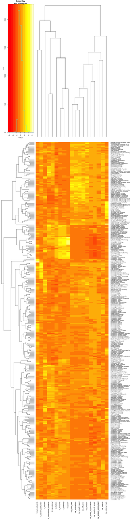

```r
heatmap.2(as.matrix(scale(univ_num)),margins = c(10, 10),trace="none",cexRow=0.68, cexCol=0.9)
```

## PCA

Let’s first run a PCA to get a rough idea of the dimensionality of the data. A PCA should help to identify factors prior to factor analysis.

```r
pca.univ<-princomp(univ_num, corr=TRUE)
summary(pca.univ)
```

```
## Importance of components:
##                              Comp.1       Comp.2       Comp.3       Comp.4
## Standard deviation     1.475800e+04 5.039055e+02 2.040688e+02 1.691069e+02
## Proportion of Variance 9.983311e-01 1.163905e-03 1.908854e-04 1.310817e-04
## Cumulative Proportion  9.983311e-01 9.994950e-01 9.996859e-01 9.998170e-01
##                              Comp.5       Comp.6       Comp.7       Comp.8
## Standard deviation     1.120510e+02 9.800906e+01 8.749133e+01 6.456796e+01
## Proportion of Variance 5.755070e-05 4.403031e-05 3.508725e-05 1.910968e-05
## Cumulative Proportion  9.998745e-01 9.999185e-01 9.999536e-01 9.999727e-01
##                              Comp.9      Comp.10      Comp.11      Comp.12
## Standard deviation     4.526075e+01 4.240224e+01 3.038578e+01 1.902264e+01
## Proportion of Variance 9.389940e-06 8.241322e-06 4.232141e-06 1.658673e-06
## Cumulative Proportion  9.999821e-01 9.999904e-01 9.999946e-01 9.999963e-01
##                             Comp.13      Comp.14      Comp.15      Comp.16
## Standard deviation     1.809471e+01 1.426726e+01 1.187997e+01 9.038450e+00
## Proportion of Variance 1.500800e-06 9.330409e-07 6.469188e-07 3.744616e-07
## Cumulative Proportion  9.999978e-01 9.999987e-01 9.999993e-01 9.999997e-01
##                             Comp.17      Comp.18      Comp.19
## Standard deviation     4.953642e+00 4.863886e+00 3.771827e+00
## Proportion of Variance 1.124782e-07 1.084392e-07 6.521129e-08
## Cumulative Proportion  9.999998e-01 9.999999e-01 1.000000e+00
```

So the first component provides 99% of the variance.

## Number of Factors to Retain

### Scree plot

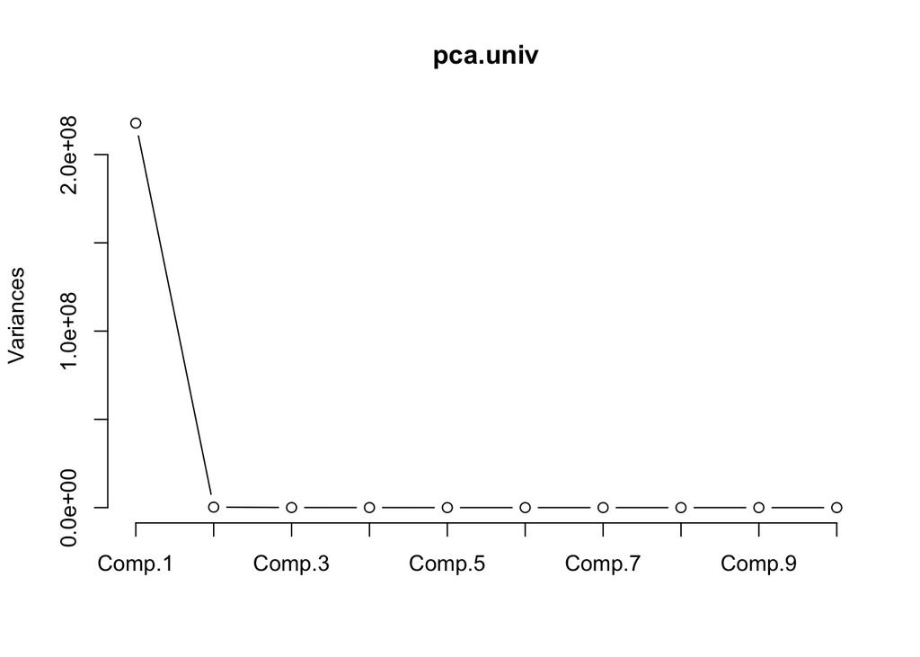

```r
plot(pca.univ,type="lines")
```

To be honest this looks like one component to rule them all, but…

```r
fa<-factanal(univ_num,factors=3,rotation="none")
fa
```

```
##
## Call:
## factanal(x = univ_num, factors = 3, rotation = "none")
##
## Uniquenesses:
##               ti_teaching          ti_international
##                     0.033                     0.005
##               ti_research              ti_citations
##                     0.108                     0.769
##                 ti_income           ti_num_students
##                     0.879                     0.836
##    ti_student_staff_ratio ti_international_students
##                     0.898                     0.297
##             cw_world_rank          cw_national_rank
##                     0.111                     0.925
##   cw_quality_of_education      cw_alumni_employment
##                     0.579                     0.657
##     cw_quality_of_faculty           cw_publications
##                     0.543                     0.109
##              cw_influence              cw_citations
##                     0.148                     0.263
##           cw_broad_impact                cw_patents
##                     0.019                     0.566
##                  cw_score
##                     0.300
##
## Loadings:
##                           Factor1 Factor2 Factor3
## ti_teaching               -0.793   0.131   0.567
## ti_international                   0.995
## ti_research               -0.760   0.242   0.506
## ti_citations              -0.436   0.194
## ti_income                 -0.193           0.289
## ti_num_students           -0.256  -0.160  -0.270
## ti_student_staff_ratio     0.263          -0.178
## ti_international_students          0.829   0.115
## cw_world_rank              0.930           0.148
## cw_national_rank           0.151  -0.222
## cw_quality_of_education    0.612  -0.142  -0.161
## cw_alumni_employment       0.522          -0.265
## cw_quality_of_faculty      0.627  -0.109  -0.229
## cw_publications            0.920           0.200
## cw_influence               0.859  -0.200   0.273
## cw_citations               0.827  -0.144   0.178
## cw_broad_impact            0.941  -0.104   0.289
## cw_patents                 0.654
## cw_score                  -0.665   0.109   0.497
##
##                Factor1 Factor2 Factor3
## SS loadings      7.528   1.989   1.438
## Proportion Var   0.396   0.105   0.076
## Cumulative Var   0.396   0.501   0.577
##
## Test of the hypothesis that 3 factors are sufficient.
## The chi square statistic is 885.4 on 117 degrees of freedom.
## The p-value is 2.88e-118
```

OK so the first component isn’t everything - just 39% of the variance.

## Rotate

```r
fa_rotate<- factanal(univ_num,factors=3,scores="regression",rotation="varimax")
fa_rotate
```

```
##
## Call:
## factanal(x = univ_num, factors = 3, scores = "regression", rotation = "varimax")
##
## Uniquenesses:
##               ti_teaching          ti_international
##                     0.033                     0.005
##               ti_research              ti_citations
##                     0.108                     0.769
##                 ti_income           ti_num_students
##                     0.879                     0.836
##    ti_student_staff_ratio ti_international_students
##                     0.898                     0.297
##             cw_world_rank          cw_national_rank
##                     0.111                     0.925
##   cw_quality_of_education      cw_alumni_employment
##                     0.579                     0.657
##     cw_quality_of_faculty           cw_publications
##                     0.543                     0.109
##              cw_influence              cw_citations
##                     0.148                     0.263
##           cw_broad_impact                cw_patents
##                     0.019                     0.566
##                  cw_score
##                     0.300
##
## Loadings:
##                           Factor1 Factor2 Factor3
## ti_teaching               -0.313  -0.917   0.168
## ti_international                           0.993
## ti_research               -0.324  -0.844   0.275
## ti_citations              -0.322  -0.296   0.200
## ti_income                         -0.348
## ti_num_students           -0.362          -0.172
## ti_student_staff_ratio     0.108   0.300
## ti_international_students                  0.834
## cw_world_rank              0.841   0.424
## cw_national_rank                   0.122  -0.226
## cw_quality_of_education    0.405   0.483  -0.156
## cw_alumni_employment       0.267   0.522
## cw_quality_of_faculty      0.376   0.548  -0.127
## cw_publications            0.864   0.375
## cw_influence               0.860   0.274  -0.193
## cw_citations               0.777   0.335  -0.142
## cw_broad_impact            0.934   0.313
## cw_patents                 0.487   0.443
## cw_score                  -0.249  -0.786   0.140
##
##                Factor1 Factor2 Factor3
## SS loadings      4.806   4.111   2.038
## Proportion Var   0.253   0.216   0.107
## Cumulative Var   0.253   0.469   0.577
##
## Test of the hypothesis that 3 factors are sufficient.
## The chi square statistic is 885.4 on 117 degrees of freedom.
## The p-value is 2.88e-118
```

Actually the 25%, 21%, and 10% of the variance are explained for the first three factors respectively.

## Compare

```r
fa_load<-as.data.frame(unclass(loadings(fa)))
fa_rotate_load<-as.data.frame(unclass(loadings(fa_rotate)))
names(fa_rotate_load)<-paste("rot",names(fa_rotate_load),sep="_")
knitr::kable(cbind(fa_load,fa_rotate_load))
```

|  | Factor1 | Factor2 | Factor3 | rot_Factor1 | rot_Factor2 | rot_Factor3 |
| --- | --- | --- | --- | --- | --- | --- |
| ti_teaching | -0.7927511 | 0.1314466 | 0.5667256 | -0.3127039 | -0.9170758 | 0.1676264 |
| ti_international | 0.0659665 | 0.9952748 | -0.0092150 | 0.0249108 | 0.0930440 | 0.9928397 |
| ti_research | -0.7597677 | 0.2419974 | 0.5063186 | -0.3239791 | -0.8436810 | 0.2746053 |
| ti_citations | -0.4357130 | 0.1937057 | 0.0608838 | -0.3216187 | -0.2957293 | 0.2004498 |
| ti_income | -0.1932791 | -0.0204550 | 0.2886119 | 0.0131838 | -0.3476837 | -0.0037734 |
| ti_num_students | -0.2562285 | -0.1600830 | -0.2701755 | -0.3621731 | 0.0605447 | -0.1715792 |
| ti_student_staff_ratio | 0.2631248 | 0.0342121 | -0.1783754 | 0.1076877 | 0.3001925 | 0.0225997 |
| ti_international_students | -0.0504921 | 0.8287421 | 0.1149198 | 0.0072558 | -0.0834831 | 0.8339948 |
| cw_world_rank | 0.9300580 | -0.0463848 | 0.1482216 | 0.8410971 | 0.4236586 | -0.0468859 |
| cw_national_rank | 0.1514506 | -0.2218496 | -0.0533444 | 0.0965105 | 0.1215299 | -0.2256465 |
| cw_quality_of_education | 0.6121061 | -0.1423337 | -0.1609927 | 0.4045657 | 0.4825714 | -0.1558938 |
| cw_alumni_employment | 0.5217795 | 0.0300663 | -0.2648218 | 0.2665453 | 0.5216370 | 0.0116931 |
| cw_quality_of_faculty | 0.6269385 | -0.1092600 | -0.2288464 | 0.3760250 | 0.5476868 | -0.1265099 |
| cw_publications | 0.9204215 | -0.0582628 | 0.2003207 | 0.8641160 | 0.3753268 | -0.0559650 |
| cw_influence | 0.8590384 | -0.1995739 | 0.2730339 | 0.8603238 | 0.2738718 | -0.1927730 |
| cw_citations | 0.8273696 | -0.1444132 | 0.1776485 | 0.7774738 | 0.3350026 | -0.1423460 |
| cw_broad_impact | 0.9413423 | -0.1039003 | 0.2894417 | 0.9343688 | 0.3134030 | -0.0971111 |
| cw_patents | 0.6544508 | 0.0017642 | -0.0731356 | 0.4870213 | 0.4431781 | -0.0078216 |
| cw_score | -0.6645907 | 0.1087540 | 0.4966650 | -0.2494765 | -0.7863135 | 0.1402030 |

## Interpret

```r
bolden<-function(x){if(abs(x[1])>=.40){return(paste("**",x,"**",sep=""))}else{return(as.character(x))}}
bolden_fact<-sapply(fa_rotate_load,bolden)
fa_rotate_load$factor1<-sapply(fa_rotate_load$rot_Factor1,bolden)
fa_rotate_load$factor2<-sapply(fa_rotate_load$rot_Factor2,bolden)
fa_rotate_load$factor3<-sapply(fa_rotate_load$rot_Factor3,bolden)
bolden_fact<-fa_rotate_load[,c("factor1","factor2","factor3")]
knitr::kable(bolden_fact)
```

|  | factor1 | factor2 | factor3 |
| --- | --- | --- | --- |
| ti_teaching | -0.312703923372568 | **-0.917075844506846** | 0.167626448503871 |
| ti_international | 0.024910834264958 | 0.0930440463051587 | **0.992839709093521** |
| ti_research | -0.323979128780365 | **-0.84368100524792** | 0.274605274444826 |
| ti_citations | -0.321618681463556 | -0.295729306861981 | 0.200449769774609 |
| ti_income | 0.0131837664027246 | -0.347683701291826 | -0.00377337122969357 |
| ti_num_students | -0.362173095741403 | 0.0605446607500951 | -0.17157922132375 |
| ti_student_staff_ratio | 0.107687748819783 | 0.300192472313257 | 0.0225996630779437 |
| ti_international_students | 0.0072558352797857 | -0.0834830540844054 | **0.833994801922067** |
| cw_world_rank | **0.841097070230699** | **0.423658572214647** | -0.046885883123079 |
| cw_national_rank | 0.0965105016632375 | 0.121529879828874 | -0.22564651897857 |
| cw_quality_of_education | **0.404565689438869** | **0.482571427394191** | -0.155893754630743 |
| cw_alumni_employment | 0.266545323423791 | **0.521637046993002** | 0.011693149648907 |
| cw_quality_of_faculty | 0.37602498115661 | **0.547686756235805** | -0.126509908221051 |
| cw_publications | **0.864115974282074** | 0.375326756402207 | -0.0559649514629531 |
| cw_influence | **0.860323777160349** | 0.273871762758984 | -0.192772982675236 |
| cw_citations | **0.777473765093619** | 0.335002637452058 | -0.142345990458393 |
| cw_broad_impact | **0.93436882397385** | 0.313402963762129 | -0.0971110735399851 |
| cw_patents | **0.487021315068845** | **0.443178087019982** | -0.00782160400891476 |
| cw_score | -0.249476491707553 | **-0.786313513481999** | 0.140202968212309 |

## US Schools

Let’s look at the subset of 70 US schools to help interpret these factors

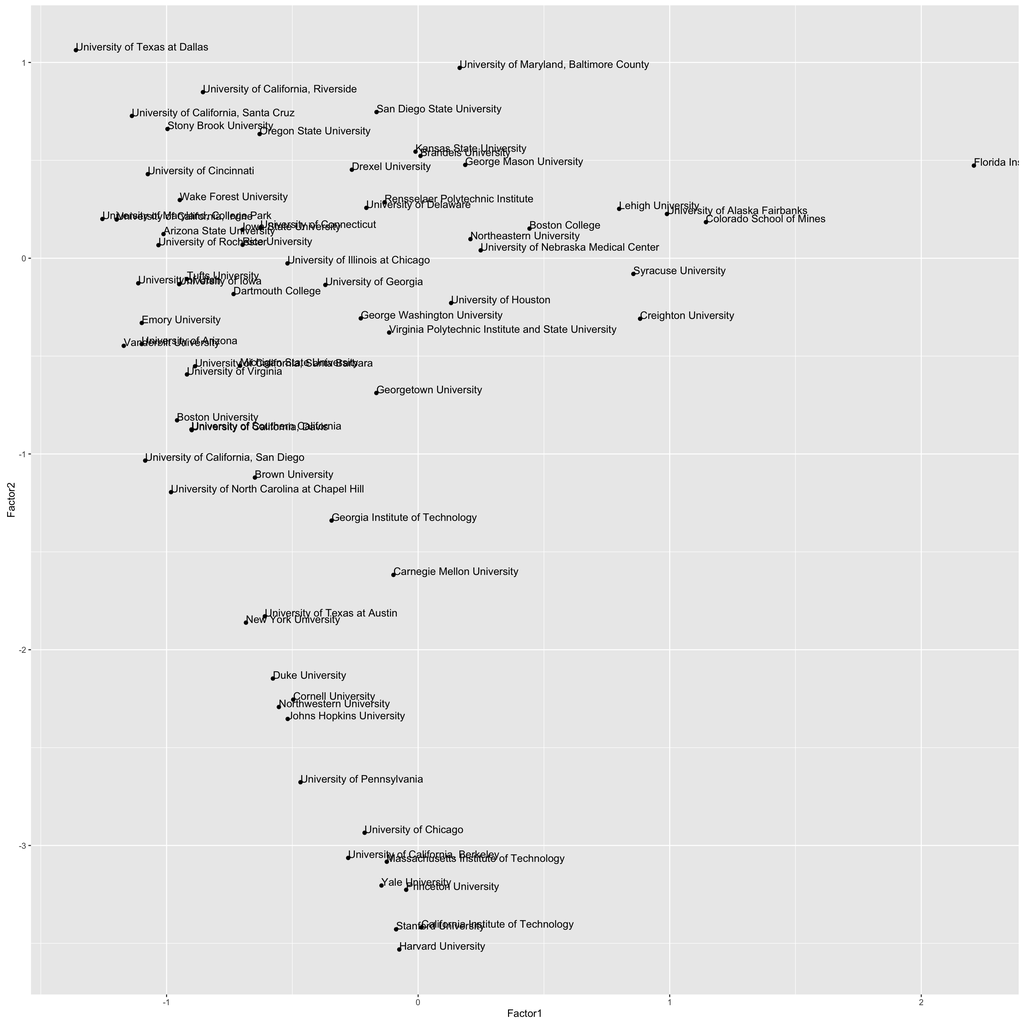

```r
scores<-as.data.frame(fa_rotate$scores)
scores$country<-univ_na$ti_country
scores$university<-univ_na$ti_university_name
scores %>% filter(country=='United States of America') -> usschools
ggplot(usschools,aes(Factor1,Factor2))+geom_point()+geom_text(aes(label=university),hjust=0, vjust=0)
```

- Factor 1 seems to be related to humanities/engineering focus
- Factor 2 is in line with general prestige or competitiveness with a favor toward larger graduate programs